# Model Seasonal ARIMA (SARIMA)

2024-11-01

## Packages

```r
library(tidyverse)
library(forecast)
library(TSA)
library(aTSA)
library(car)
library(lmtest)
```

## Pendahuluan

**Seasonal Autoregressive Integrated Moving Average (SARIMA)** merupakan pengembangan dari model Autoregressive Integrated Moving Average (ARIMA) pada data deret waktu yang memiliki pola musiman.

Model ARIMA musiman menggabungkan faktor-faktor non-musiman (regular) dan musiman dalam model multiplikasi, dengan notasi $ARIMA(p,d,q)×(P,D,Q)_s$ dengan:

- *p = non-seasonal AR order,*
- *d = non-seasonal differencing,*
- *q = non-seasonal MA order,*
- *P = seasonal AR order,*
- *D = seasonal differencing,*
- *Q = seasonal MA order,*
- *s = time span of repeating seasonal pattern.*

Tahapan identifikasi model SARIMA sama halnya seperti yang dilakukan pada model ARIMA regular atau model ARIMA non-seasonal, yaitu :

- Plot time series
- Identifikasi model
- Pendugaan parameter model
- Seleksi Model
- Melakukan peramalan menggunakan model terbaik

## Impor Data

```r
DATAKAGGLE <- read.csv("C://Users//Jidan statistik//Downloads//Dataset.csv", header = TRUE)
head(DATAKAGGLE)
```

```
##         Date Inbound Outbound  Total
## 1 31/01/1985  263795   208770 472565
## 2 28/02/1985  204953   179222 384175
## 3 31/03/1985  209513   231582 441095
## 4 30/04/1985  182673   214403 397076
## 5 31/05/1985  198902   224350 423252
## 6 30/06/1985  193943   209080 403023
```

```r
#hapus variabel inbound dan outbound
DATAKAGGLE<-DATAKAGGLE[,!names(DATAKAGGLE) %in% c("Inbound","Outbound")]
DATAKAGGLE
```

```
##           Date   Total
## 1   31/01/1985  472565
## 2   28/02/1985  384175
## 3   31/03/1985  441095
## 4   30/04/1985  397076
## 5   31/05/1985  423252
## 6   30/06/1985  403023
## 7   31/07/1985  402775
## 8   31/08/1985  445703
## 9   30/09/1985  441150
## 10  31/10/1985  427581
## 11  30/11/1985  445214
## 12  31/12/1985  516764
## 13  31/01/1986  529800
## 14  28/02/1986  411692
```

[output cut: 459 more lines]

```r
#jadikan data dari periode 1-400
data1<-window(DATAKAGGLE$Total, start=1, end=400)
data1<-ts(data1,frequency=12,start=c(1965,1))
class(data1)
```

```
## [1] "ts"
```

## Eksplorasi Data

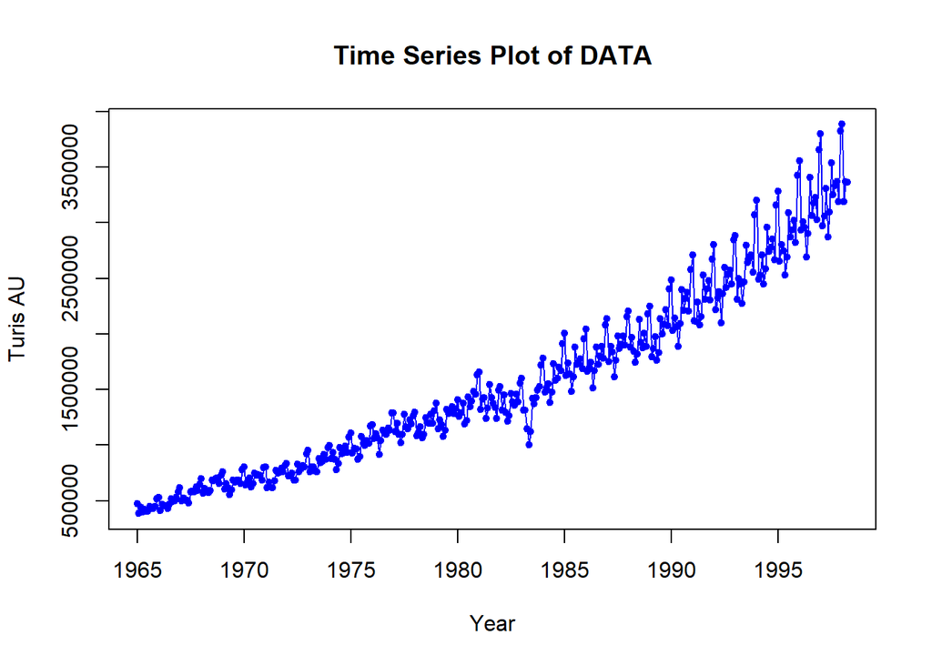

```r
ts.plot(data1, type="l", xlab = "Year", ylab=" Turis AU ", col="blue")
title(main = "Time Series Plot of DATA", cex.sub = 0.8)
points(data1, pch = 20, col = "blue")
```

```r
dec.co2 <- decompose(data1)
dec.co2
```

```
## $x
##          Jan     Feb     Mar     Apr     May     Jun     Jul     Aug     Sep
## 1965  472565  384175  441095  397076  423252  403023  402775  445703  441150
## 1966  529800  411692  466973  452302  454437  429986  468522  517035  488399
## 1967  615083  497167  520467  504091  503746  481180  578017  582982  577253
## 1968  694638  567891  608905  586001  572184  589426  686808  679612  695302
## 1969  759105  605516  652597  614561  554201  596871  687601  662764  683148
## 1970  805057  642429  674544  706087  622084  654316  747907  727970  735768
## 1971  803517  617877  667751  620954  615795  680909  773907  746672  761540
## 1972  836957  723041  720362  749081  684100  683574  829566  756952  786876
## 1973  954950  762122  802406  801714  765014  762046  875868  840410  851241
## 1974  996876  878229  936622  868914  778175  833127  975958  921183  931157
## 1975 1108644  929699  969214  967666  869725  899148 1079991 1017517  994897
## 1976 1184228 1061390 1099872 1061994  915768 1037087 1132101 1106417 1093769
## 1977 1289597 1119171 1197457 1092930 1019217 1093260 1275058 1161855 1147596
```

[output cut: 353 more lines]

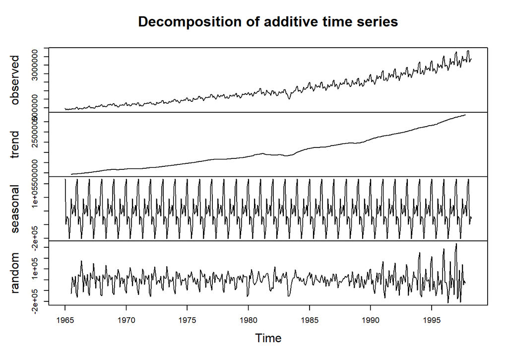

```r
plot(dec.co2)
```

Secara eksplorasi, terlihat adanya kecenderungan data memiliki tren naik dan perilaku berulang kecenderungan musiman) dalam deret tersebut. Kecenderungan musiman dapat dilihat dengan lebih jelas dengan menampilkan deret waktu per tahun.

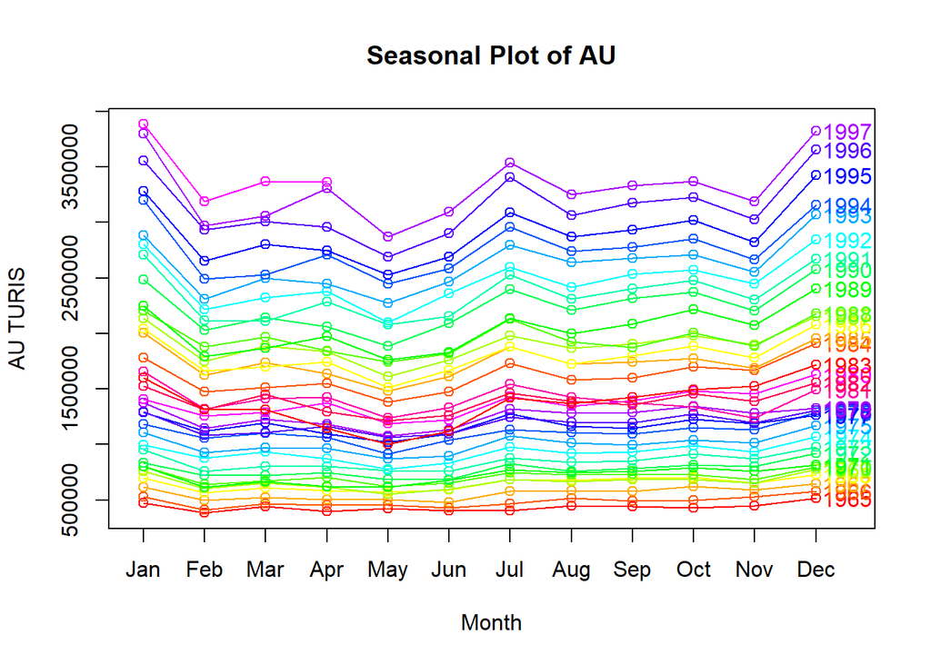

```r
seasonplot(data1,12,main="Seasonal Plot of AU", ylab="AU TURIS",
           year.labels = TRUE, col=rainbow(18))
```

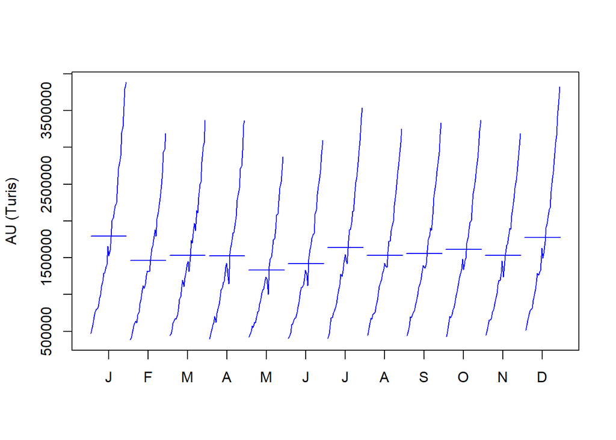

```r
monthplot(data1,ylab="AU (Turis)", col="blue")
```

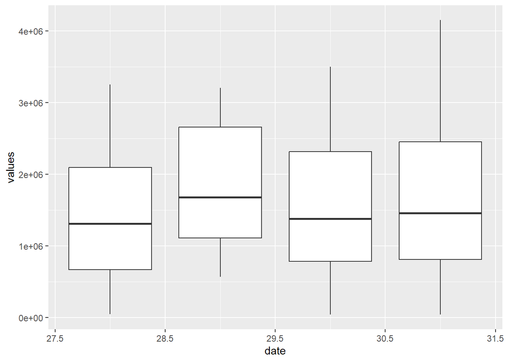

```r
frame<-data.frame(values=as.matrix(DATAKAGGLE$Total), date=lubridate::year(zoo::as.Date(DATAKAGGLE$Date)))

library(ggplot2)
ggplot(frame,aes(y=values,x=date,group=date))+
  geom_boxplot()
```

## Uji Homogenitas

Uji asumsi formal terhadap kehomogenan ragam yang digunakan yaitu *Fligner-Killen test*, dimana:

$H_0$ : Ragam homogen

$H_1$ : Ragam tidak homogen

```r
library(car)
fligner.test(values ~ date, data=frame)
```

```
##
##  Fligner-Killeen test of homogeneity of variances
##
## data:  values by date
## Fligner-Killeen:med chi-squared = 1.7939, df = 3, p-value = 0.6163
```

Berdasarkan hasil uji *Fligner-Killeen* dengan menggunakan taraf signifikansi $\alpha=5\%$ didapatkan *p-value* sebesar 0.6163 $p-value=0.6163>\alpha=0.05$ sehingga tak tolak $H_0$ atau dengan kata lain **ragam data sudah stasioner**.

## Pembagian Data

Pembagian data dilakukan dengan mengambil sekitar 80% data awal (320 observasi) sebagai data latih dan 20% sisanya (80 observasi) sebagai data uji.

```r
train.ts <- subset(data1,start=1,end=320)
test.ts <- subset(data1,start=321,end=400)
```

### Plot Data Latih

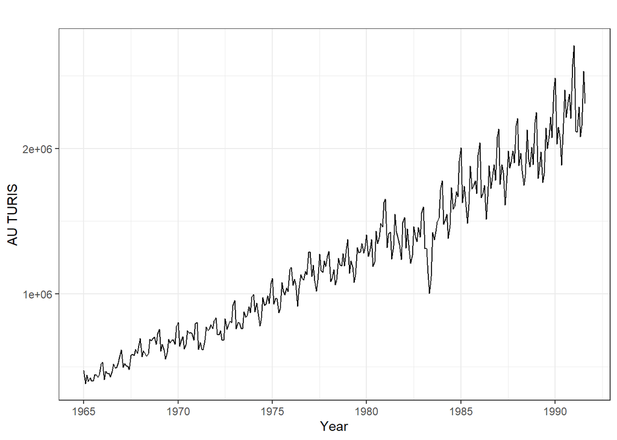

```r
autoplot(train.ts) + theme_bw() + xlab("Year") + ylab("AU TURIS")
```

### Plot Data Uji

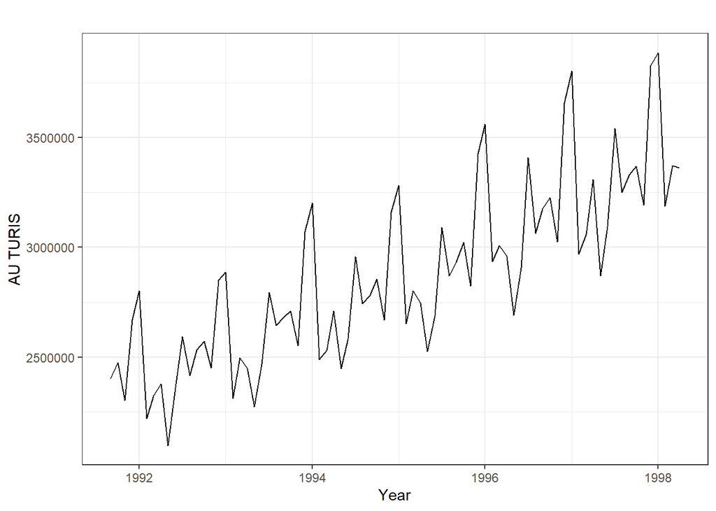

```r
autoplot(test.ts) + theme_bw() + xlab("Year") + ylab("AU TURIS")
```

## Non-Seasonal ARIMA

### Kestasioneran Data

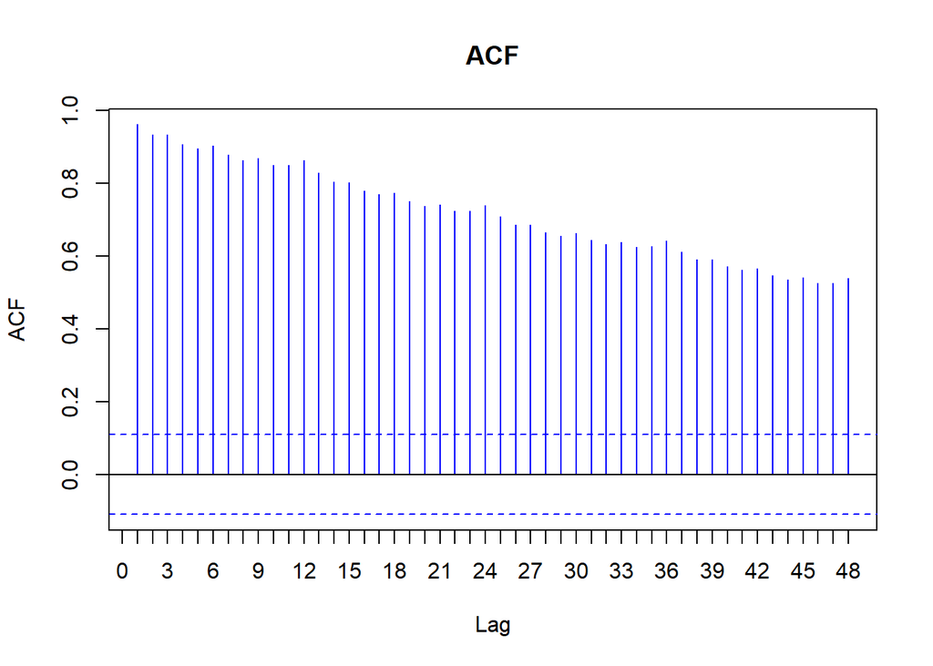

```r
acf0 <- acf(train.ts,main="ACF",lag.max=48,xaxt="n", col="blue")
axis(1, at=0:48/12, labels=0:48)
```

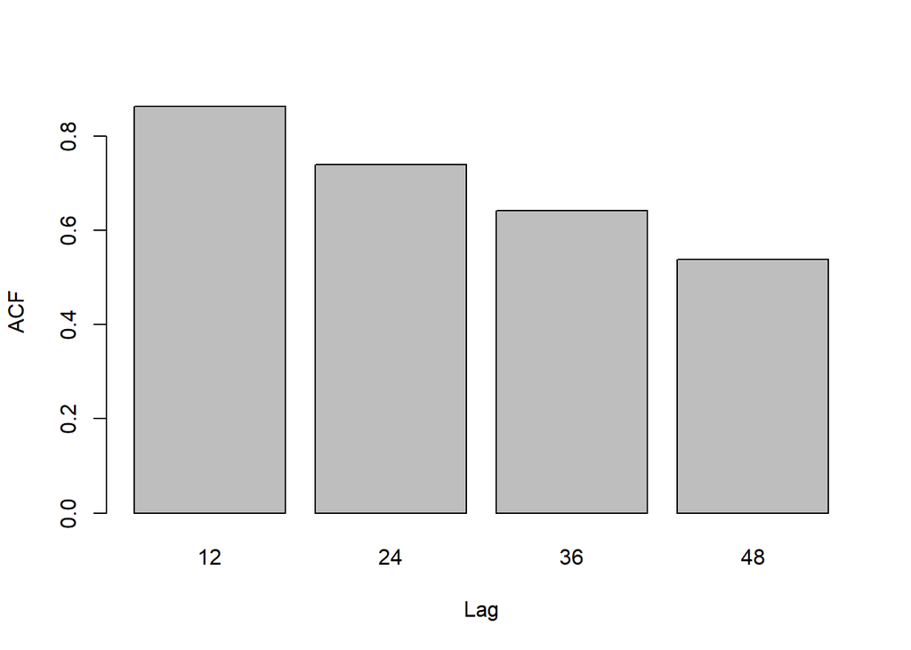

```r
acf0$lag <- acf0$lag * 12
acf0.1 <- as.data.frame(cbind(acf0$acf,acf0$lag))
acf0.2 <- acf0.1[which(acf0.1$V2%%12==0),]
barplot(height = acf0.2$V1,
names.arg=acf0.2$V2, ylab="ACF", xlab="Lag")
```

```r
tseries::adf.test(train.ts)
```

```
##
##  Augmented Dickey-Fuller Test
##
## data:  train.ts
## Dickey-Fuller = -5.1563, Lag order = 6, p-value = 0.01
## alternative hypothesis: stationary
```

$H_0$ : Data tidak stasioner dalam rataan

$H_1$ : Data stasioner dalam rataan

Berdasarkan uji ADF tersebut, didapat *p-value* sebesar 0.01 yang lebih kecil dari taraf nyata 5% sehingga tolak $H_0$ dan menandakan bahwa data stasioner dalam rataan. akan tetapi Hal ini tidak sesuai dengan hasil eksplorasi menggunakan plot time series dan plot ACF. sehingga tetap diperlukan differencing karena plot ACF terlihat jelas bahwa data tidak stasioner dalam rataan.

### Pembedaan

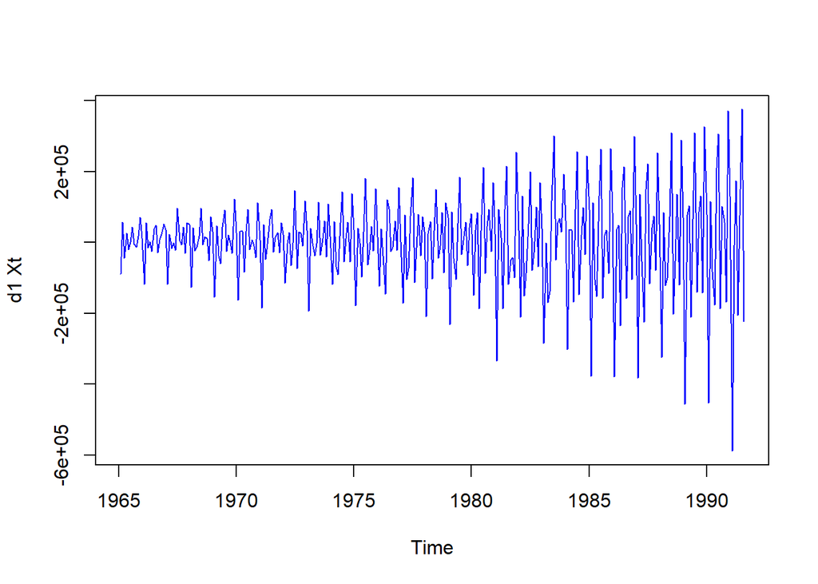

```r
d1 <- diff(train.ts)
ts.plot(d1, type="l", ylab="d1 Xt", col="blue")
```

*Differencing non-seasonal* $d=1$ jika dilihat berdasarkan plot di atas berhasil mengatasi ketidakstasioneran dalam rataan untuk komponen *non-seasonal*.

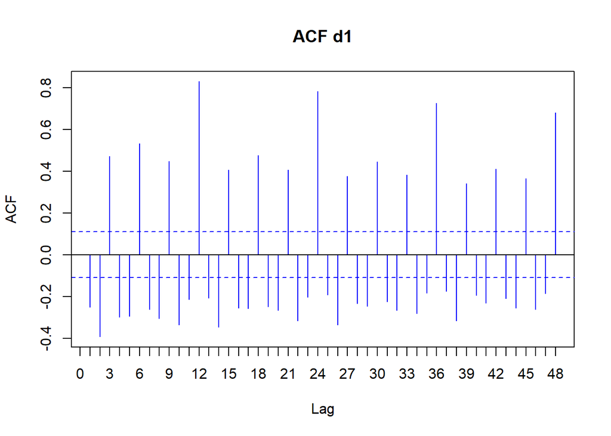

```r
acf1 <- acf(d1,lag.max=48,xaxt="n", main="ACF d1", col="blue")
axis(1, at=0:48/12, labels=0:48)
```

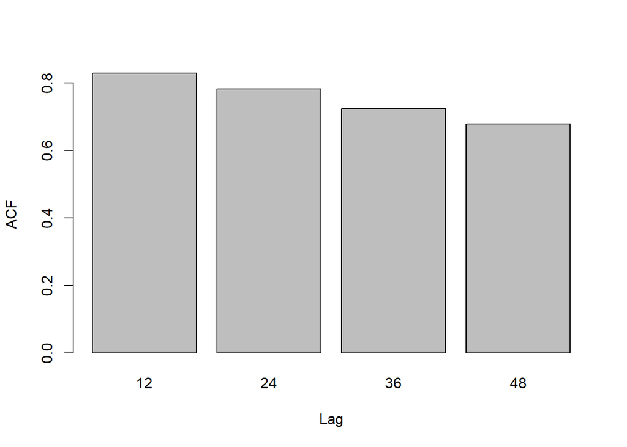

```r
acf2 <- acf1$lag <- acf1$lag * 12
acf1.1 <- as.data.frame(cbind(acf1$acf,acf1$lag))
acf1.2 <- acf1.1[which(acf1.1$V2%%12==0),]
barplot(height = acf1.2$V1, names.arg=acf1.2$V2, ylab="ACF", xlab="Lag")
```

Plot ACF data *non-seasonal differencing* $d=1$ mengkonfirmasi kestasioneran komponen *non-seasonal* (namun perhatikan lag 12,24, dst), pada *series* *seasonal* **belum stasioner**. Hal ini menunjukkan adanya kecenderungan musiman

## Seasonal ARIMA

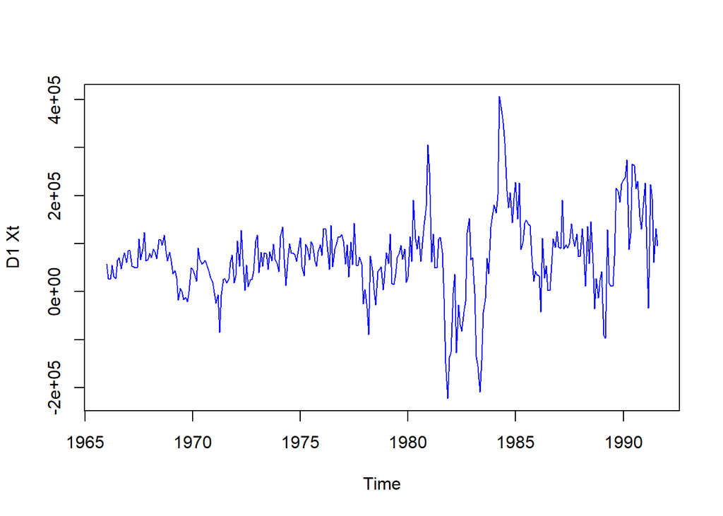

```r
D1 <- diff(train.ts,12)
ts.plot(D1, type="l", ylab="D1 Xt", col="blue")
```

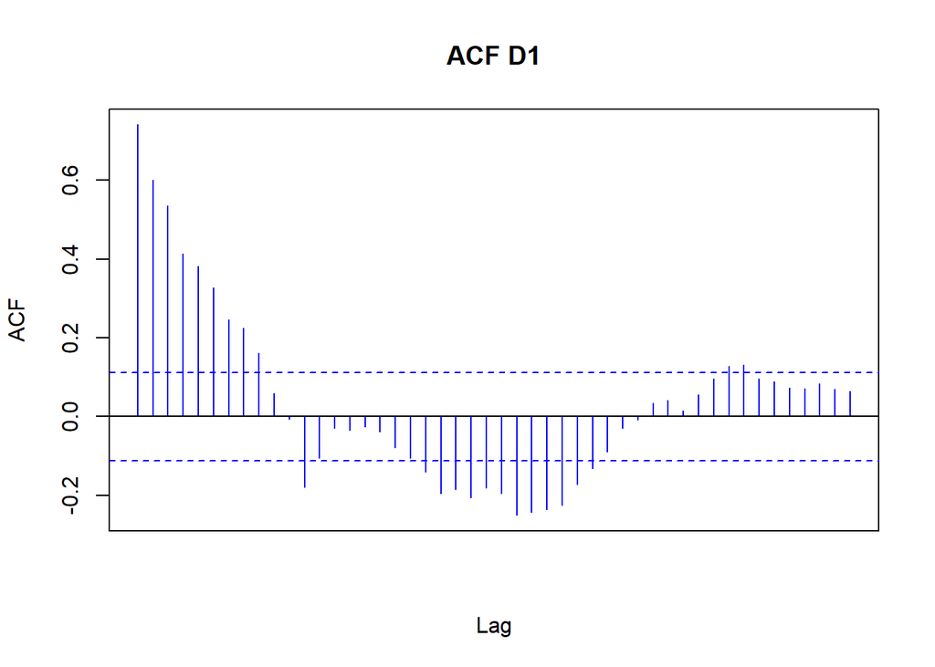

```r
acf2<-acf(D1,lag.max=48,xaxt="n", main="ACF D1", col="blue")
```

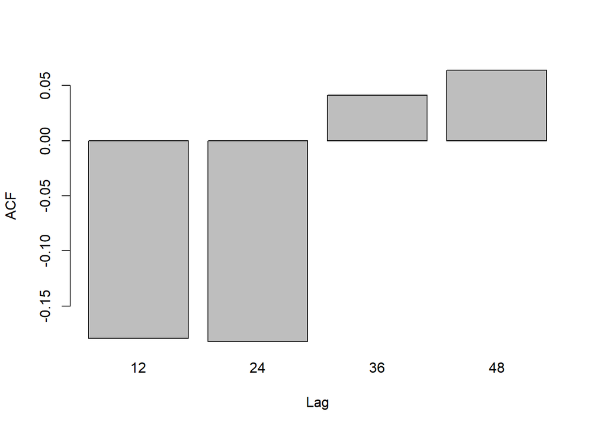

```r
acf2$lag <- acf2$lag * 12
acf2.1 <- as.data.frame(cbind(acf2$acf,acf2$lag))
acf2.2 <- acf2.1[which(acf2.1$V2%%12==0),]
barplot(height = acf2.2$V1, names.arg=acf2.2$V2, ylab="ACF", xlab="Lag")
```

Untuk menghilangkan kecenderungan musiman dilakukan pembedaan musiman terhadap deret hasil pembedaan pertama.

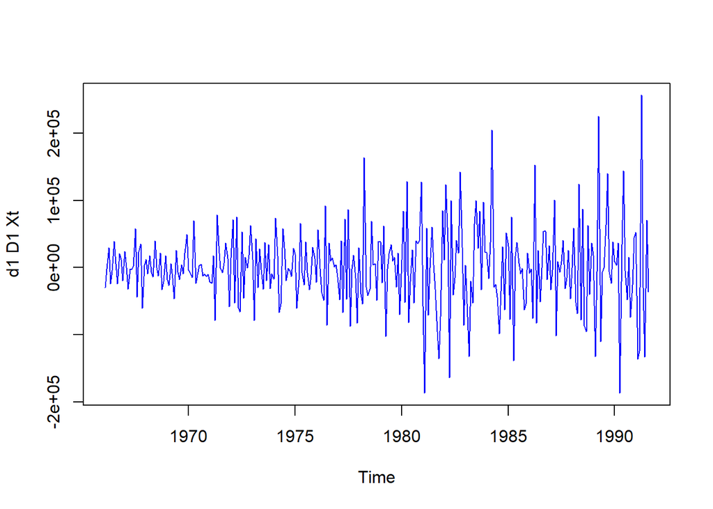

```r
d1D1 <- diff(D1)
ts.plot(d1D1, type="l", ylab="d1 D1 Xt", col="blue")
```

Setelah pembedaan pertama dan pembedaan musiman tampak bahwa deret sudah tidak memiliki kecenderungan apapun. Selanjutnya penentuan ordo *p*, *q* dan *P*, *Q* dapat dilakukan menggunakan plot ACF dan PACF contoh dari deret hasil pembedaan pertama dan pembedaan musiman tersebut.

### Identifikasi Model

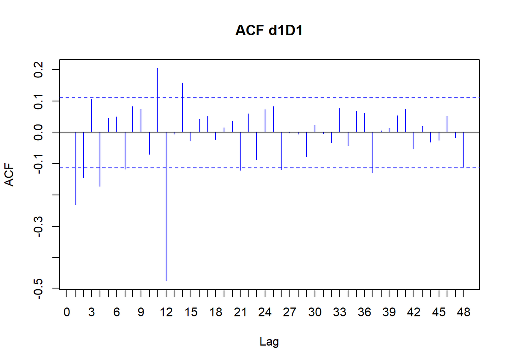

```r
acf3 <- acf(d1D1,lag.max=48,xaxt="n", main="ACF d1D1", col="blue")
axis(1, at=0:48/12, labels=0:48)
```

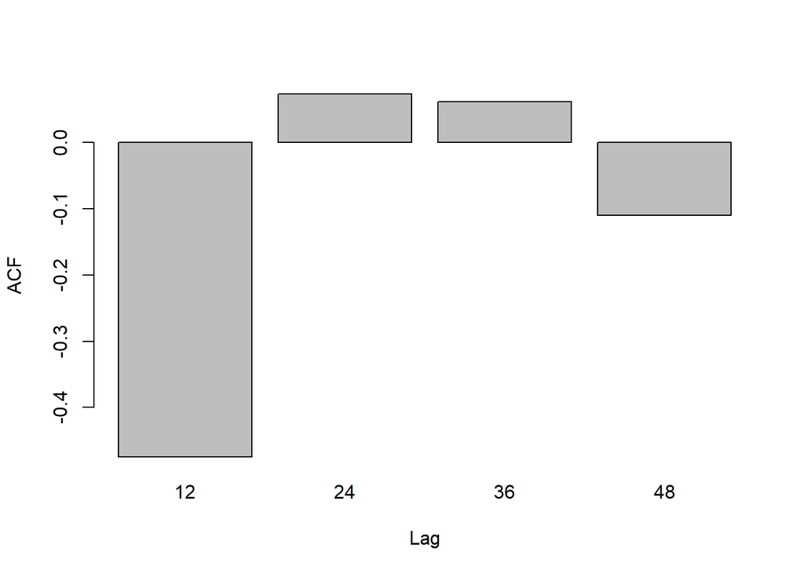

```r
acf3$lag <- acf3$lag * 12
acf3.1 <- as.data.frame(cbind(acf3$acf,acf3$lag))
acf3.2 <- acf3.1[which(acf3.1$V2%%12==0),]
barplot(height = acf3.2$V1, names.arg=acf3.2$V2, ylab="ACF",
xlab="Lag")
```

Berdasarkan plot ACF contoh lag 1 signifikan sehingga dipilih ordo *q*=1 , dan lag 12 adalah satu-satunya lag musiman yang signifikan sehingga order *Q*=1.

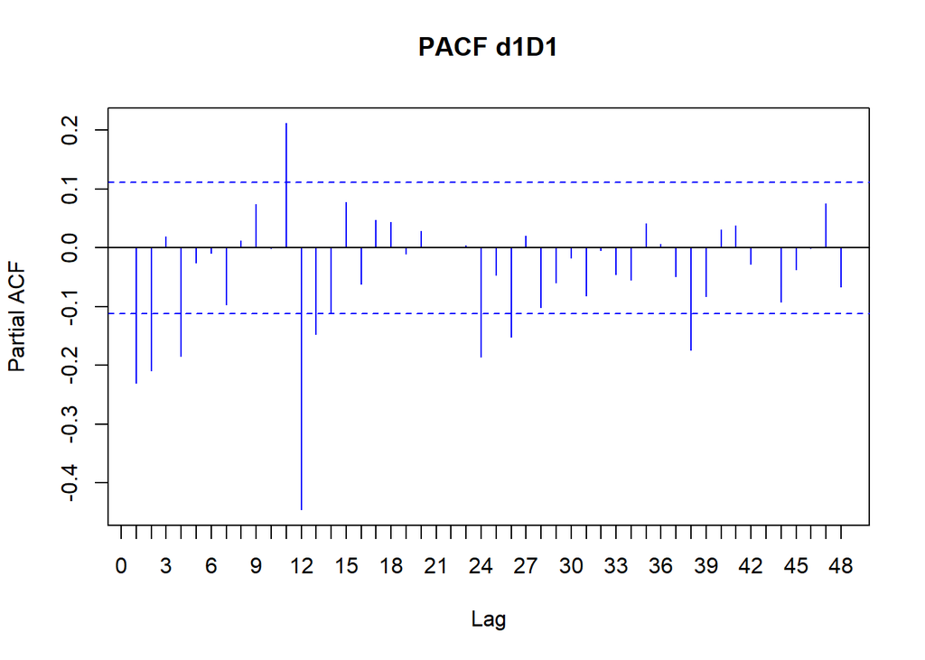

```r
pacf3 <- pacf(d1D1,lag.max=48,xaxt="n", main="PACF d1D1", col="blue")
axis(1, at=0:48/12, labels=0:48)
```

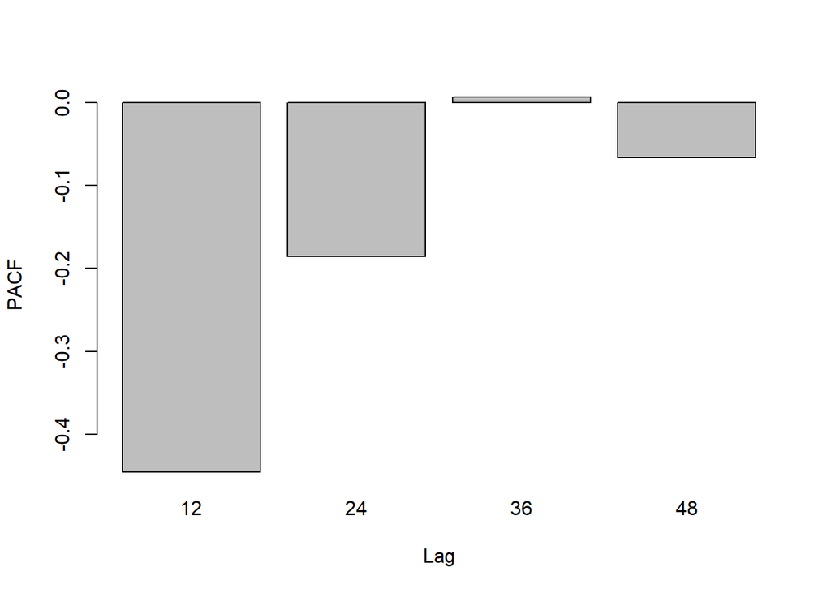

```r
pacf3$lag <- pacf3$lag * 12
pacf3.1 <- as.data.frame(cbind(pacf3$acf,pacf3$lag))
pacf3.2 <- pacf3.1[which(pacf3.1$V2%%12==0),]
barplot(height = pacf3.2$V1, names.arg=pacf3.2$V2, ylab="PACF", xlab="Lag")
```

Plot PACF contoh menunjukkan *Tails Off* pada lag-1 sehingga ordo *q*=1, sementara pada pola musimannya tidak terlihat model AR yang terbentuk karena cenderung *tails-off*.

**EACF**

```r
TSA::eacf(d1D1)
```

```
## AR/MA
##   0 1 2 3 4 5 6 7 8 9 10 11 12 13
## 0 x x o x o o x o o o x  x  o  x
## 1 x x o x o o o o o o o  x  o  x
## 2 o x o x o o o o o o o  x  o  x
## 3 o x x o o o o o o o o  x  o  x
## 4 x o x x o o o o o o o  x  x  o
## 5 o o x o o o o o o o o  x  x  o
## 6 o x x x o o o o o o o  x  x  o
## 7 o x o x o o o o o o o  x  x  o
```

- $ARIMA(0,1,1)\times(0,1,1)_{12}$
- $ARIMA(1,1,0)\times(0,1,1)_{12}$
- $ARIMA(1,1,1)\times(0,1,1)_{12}$
- $ARIMA(0,1,4)\times(0,1,1)_{12}$
- $ARIMA(1,1,4)\times(0,1,1)_{12}$

### Pendugaan Parameter

```r
#ARIMA(0,1,1)x(0,1,1)12
tmodel1 <- Arima(train.ts,order=c(0,1,1),seasonal=c(0,1,1))
summary(tmodel1)
```

```
## Series: train.ts
## ARIMA(0,1,1)(0,1,1)[12]
##
## Coefficients:
##           ma1     sma1
##       -0.3790  -0.5761
## s.e.   0.0627   0.0417
##
## sigma^2 = 2.365e+09:  log likelihood = -3750.24
## AIC=7506.48   AICc=7506.56   BIC=7517.66
##
## Training set error measures:
##                    ME     RMSE      MAE         MPE    MAPE      MASE      ACF1
## Training set 789.2829 47474.53 34792.36 -0.08067495 2.90048 0.3914613 0.0531959
```

```r
lmtest::coeftest(tmodel1)
```

```
##
## z test of coefficients:
##
##       Estimate Std. Error  z value  Pr(>|z|)
## ma1  -0.379014   0.062706  -6.0443 1.501e-09 ***
## sma1 -0.576143   0.041730 -13.8065 < 2.2e-16 ***
## ---
## Signif. codes:  0 '***' 0.001 '**' 0.01 '*' 0.05 '.' 0.1 ' ' 1
```

```r
#ARIMA(1,1,0)x(0,1,1)12
tmodel2 <- Arima(train.ts,order=c(1,1,0),seasonal=c(0,1,1))
summary(tmodel2)
```

```
## Series: train.ts
## ARIMA(1,1,0)(0,1,1)[12]
##
## Coefficients:
##           ar1     sma1
##       -0.2351  -0.5622
## s.e.   0.0555   0.0419
##
## sigma^2 = 2.464e+09:  log likelihood = -3756.39
## AIC=7518.77   AICc=7518.85   BIC=7529.95
##
## Training set error measures:
##                    ME     RMSE      MAE        MPE     MAPE      MASE
## Training set 558.4818 48464.78 35598.52 -0.0837216 2.973953 0.4005317
##                    ACF1
## Training set -0.0652924
```

```r
lmtest::coeftest(tmodel2)
```

```
##
## z test of coefficients:
##
##       Estimate Std. Error  z value  Pr(>|z|)
## ar1  -0.235132   0.055543  -4.2333 2.303e-05 ***
## sma1 -0.562166   0.041928 -13.4078 < 2.2e-16 ***
## ---
## Signif. codes:  0 '***' 0.001 '**' 0.01 '*' 0.05 '.' 0.1 ' ' 1
```

```r
#ARIMA(1,1,1)x(0,1,1)12
tmodel3 <- Arima(train.ts,order=c(1,1,1),seasonal=c(0,1,1))
summary(tmodel3)
```

```
## Series: train.ts
## ARIMA(1,1,1)(0,1,1)[12]
##
## Coefficients:
##          ar1      ma1     sma1
##       0.3785  -0.7091  -0.5823
## s.e.  0.1340   0.1055   0.0416
##
## sigma^2 = 2.319e+09:  log likelihood = -3746.82
## AIC=7501.65   AICc=7501.78   BIC=7516.55
##
## Training set error measures:
##                    ME     RMSE      MAE         MPE     MAPE      MASE
## Training set 1064.078 46932.46 34314.71 -0.06931146 2.868393 0.3860871
##                    ACF1
## Training set 0.00748021
```

```r
lmtest::coeftest(tmodel3)
```

```
##
## z test of coefficients:
##
##       Estimate Std. Error  z value  Pr(>|z|)
## ar1   0.378459   0.133959   2.8252  0.004725 **
## ma1  -0.709132   0.105481  -6.7228 1.782e-11 ***
## sma1 -0.582314   0.041608 -13.9951 < 2.2e-16 ***
## ---
## Signif. codes:  0 '***' 0.001 '**' 0.01 '*' 0.05 '.' 0.1 ' ' 1
```

```r
#ARIMA(0,1,4)x(0,1,1)12
tmodel4 <- Arima(train.ts,order=c(0,1,4),seasonal=c(0,1,1))
summary(tmodel4)
```

```
## Series: train.ts
## ARIMA(0,1,4)(0,1,1)[12]
##
## Coefficients:
##           ma1      ma2     ma3      ma4     sma1
##       -0.2729  -0.2385  0.1480  -0.1895  -0.6107
## s.e.   0.0562   0.0590  0.0589   0.0603   0.0406
##
## sigma^2 = 2.19e+09:  log likelihood = -3737.49
## AIC=7486.99   AICc=7487.27   BIC=7509.35
##
## Training set error measures:
##                    ME     RMSE      MAE         MPE     MAPE     MASE
## Training set 1152.416 45461.17 33142.75 -0.05434594 2.769517 0.372901
##                      ACF1
## Training set -0.005673499
```

```r
lmtest::coeftest(tmodel4)
```

```
##
## z test of coefficients:
##
##       Estimate Std. Error  z value  Pr(>|z|)
## ma1  -0.272901   0.056218  -4.8543 1.208e-06 ***
## ma2  -0.238504   0.058993  -4.0430 5.278e-05 ***
## ma3   0.147975   0.058910   2.5119  0.012009 *
## ma4  -0.189547   0.060342  -3.1412  0.001682 **
## sma1 -0.610706   0.040625 -15.0328 < 2.2e-16 ***
## ---
## Signif. codes:  0 '***' 0.001 '**' 0.01 '*' 0.05 '.' 0.1 ' ' 1
```

```r
#ARIMA(1,1,4)x(0,1,1)12
tmodel5 <- Arima(train.ts,order=c(1,1,4),seasonal=c(0,1,1))
summary(tmodel5)
```

```
## Series: train.ts
## ARIMA(1,1,4)(0,1,1)[12]
##
## Coefficients:
##           ar1      ma1      ma2     ma3      ma4     sma1
##       -0.1003  -0.1765  -0.2603  0.1230  -0.1853  -0.6089
## s.e.   0.2613   0.2566   0.0824  0.0858   0.0643   0.0411
##
## sigma^2 = 2.196e+09:  log likelihood = -3737.43
## AIC=7488.86   AICc=7489.23   BIC=7514.94
##
## Training set error measures:
##                   ME     RMSE      MAE         MPE     MAPE     MASE
## Training set 1134.27 45453.26 33130.49 -0.05535453 2.770151 0.372763
##                     ACF1
## Training set -0.00235239
```

```r
lmtest::coeftest(tmodel5)
```

```
##
## z test of coefficients:
##
##       Estimate Std. Error  z value  Pr(>|z|)
## ar1  -0.100302   0.261332  -0.3838  0.701118
## ma1  -0.176516   0.256579  -0.6880  0.491477
## ma2  -0.260312   0.082377  -3.1600  0.001578 **
## ma3   0.122990   0.085766   1.4340  0.151568
## ma4  -0.185262   0.064315  -2.8805  0.003970 **
## sma1 -0.608877   0.041129 -14.8042 < 2.2e-16 ***
## ---
## Signif. codes:  0 '***' 0.001 '**' 0.01 '*' 0.05 '.' 0.1 ' ' 1
```

```r
AICKandidatModel <- c(tmodel1$aic, tmodel2$aic, tmodel3$aic,
                      tmodel4$aic, tmodel5$aic)
AICcKandidatModel <- c(tmodel1$aicc, tmodel2$aicc, tmodel3$aicc,
                       tmodel4$aicc, tmodel5$aicc)
BICKandidatModel <- c(tmodel1$bic, tmodel2$bic, tmodel3$bic,
                      tmodel4$bic, tmodel5$bic)
KandidatModelARIMA <- c("ARIMA(0,1,1)(0,1,1)12", "ARIMA(1,1,0)(0,1,1)12",
                        "ARIMA(1,1,1)(0,1,1)12", "ARIMA(0,1,4)(0,1,1)12",
                        "ARIMA(1,1,4)(0,1,1)12")
compmodelARIMA <- cbind(KandidatModelARIMA, AICKandidatModel,
                        AICcKandidatModel, BICKandidatModel)
colnames(compmodelARIMA) <- c("Kandidat Model", "Nilai AIC",
                              "Nilai AICc", "Nilai BIC")
compmodelARIMA <- as.data.frame(compmodelARIMA)
compmodelARIMA
```

```
##          Kandidat Model        Nilai AIC       Nilai AICc        Nilai BIC
## 1 ARIMA(0,1,1)(0,1,1)12 7506.47579675113 7506.55500467193  7517.6563399939
## 2 ARIMA(1,1,0)(0,1,1)12 7518.77065089242 7518.84985881321 7529.95119413518
## 3 ARIMA(1,1,1)(0,1,1)12 7501.64624202689 7501.77869235802 7516.55363301724
## 4 ARIMA(0,1,4)(0,1,1)12 7486.98908103642 7487.26908103642 7509.35016752195
## 5 ARIMA(1,1,4)(0,1,1)12 7488.85532391997 7489.22990585977 7514.94325815308
```

Model **terbaik** berdasarkan nilai **AIC dan AICc terkecil** dari kandidat model **yaitu** $ARIMA(0,1,4)\times(0,1,1)_{12}$, tetapi dengan mempertimbangkan signifikansi parameter dan kesederhanaan model akan dipilih $ARIMA(0,1,1)\times(0,1,1)_{12}$

```r
model.auto.arima <- auto.arima(train.ts)
summary(model.auto.arima)
```

```
## Series: train.ts
## ARIMA(3,1,3)(0,1,2)[12]
##
## Coefficients:
##           ar1     ar2     ar3      ma1      ma2      ma3     sma1    sma2
##       -0.1655  0.0501  0.7146  -0.0760  -0.2826  -0.5824  -0.7526  0.1665
## s.e.   0.0893  0.0888  0.0735   0.1058   0.1063   0.1117   0.0690  0.0560
##
## sigma^2 = 2.059e+09:  log likelihood = -3727.91
## AIC=7473.81   AICc=7474.42   BIC=7507.36
##
## Training set error measures:
##                    ME     RMSE     MAE           MPE     MAPE      MASE
## Training set 2323.728 43867.34 32267.4 -0.0004996375 2.694192 0.3630521
##                     ACF1
## Training set -0.01987034
```

```r
lmtest::coeftest(model.auto.arima)
```

```
##
## z test of coefficients:
##
##       Estimate Std. Error  z value  Pr(>|z|)
## ar1  -0.165487   0.089288  -1.8534  0.063823 .
## ar2   0.050132   0.088802   0.5645  0.572390
## ar3   0.714564   0.073459   9.7274 < 2.2e-16 ***
## ma1  -0.076026   0.105824  -0.7184  0.472499
## ma2  -0.282602   0.106277  -2.6591  0.007835 **
## ma3  -0.582352   0.111669  -5.2150 1.838e-07 ***
## sma1 -0.752596   0.069030 -10.9024 < 2.2e-16 ***
## sma2  0.166480   0.056025   2.9715  0.002963 **
## ---
## Signif. codes:  0 '***' 0.001 '**' 0.01 '*' 0.05 '.' 0.1 ' ' 1
```

### Diagnostik Model

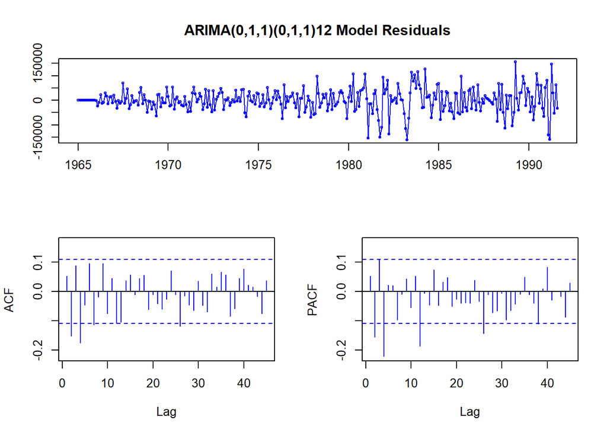

```r
tsdisplay(residuals(tmodel1), lag.max=45,
          main='ARIMA(0,1,1)(0,1,1)12 Model Residuals', col="blue")
```

```r
#Eksplorasi
sisaan.model1 <- tmodel1$residuals
par(mfrow=c(2,2))
car::qqPlot(sisaan.model1)
```

```
## [1] 220 315
```

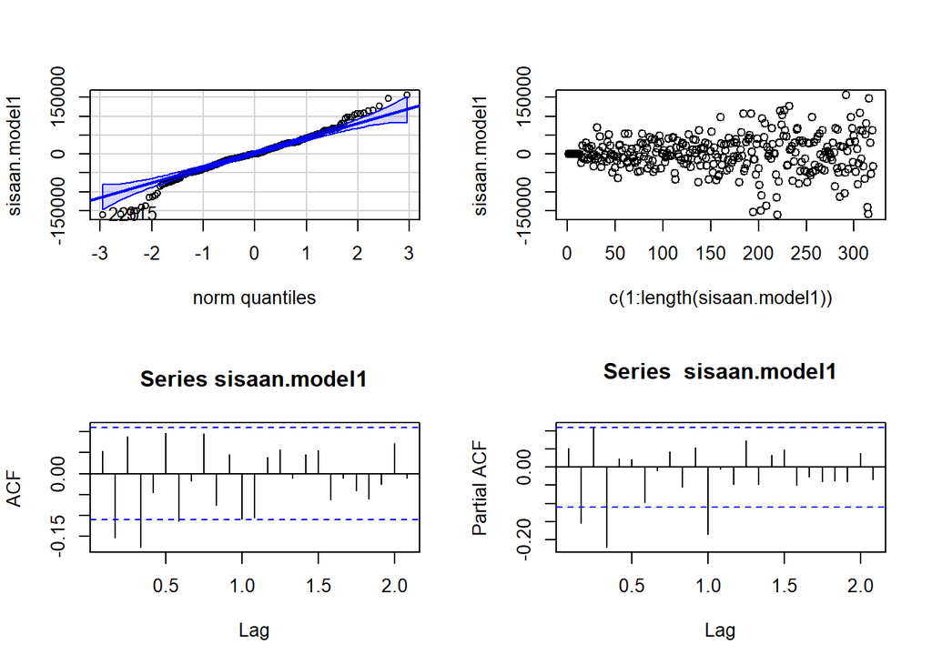

```r
plot(c(1:length(sisaan.model1)),sisaan.model1)
acf(sisaan.model1)
pacf(sisaan.model1)
```

```r
par(mfrow = c(1,1))
```